# Part II - (Ford GoBike System Data 2019)

## by (Oluwatosin Olanrewaju)

## Investigation Overview

**Exploring the variables of the Ford GoBike System Data 2019 of the greater San Francisco Bay area, visualizing the dataset variables to see there impact of time duration of riding on other variables.**

## Dataset Overview

> **This data set 'Ford GoBike System Data' includes information about individual rides in a bike-sharing system covering the greater San Francisco Bay area for the year 2019.**

Rows: 174,952 Columns: 14

In the investigation I used the following features in the cleaned 'df.csv':

> user_type (values: “Subscriber” or “Customer”)

> duration_min (duration of trip in minutes)

> t_hour (hour of start of biketrip)

> t_day (day of week of start of biketrip)

> Age and Gender

## Most frequent trip duration

> **The average trip duration of bike users is 704 secs and the plot above shows a rightly skewed distribution.**

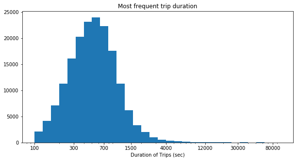

# (Daily Trips Frequency)

> Weekends has far less trips than weekdays.

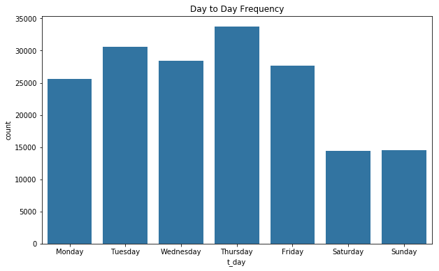

## The Distribution of the Age of the Users

> **From the visual below, we notice that most users are 25-35 years old. Plot distribution is rightly skewed.**

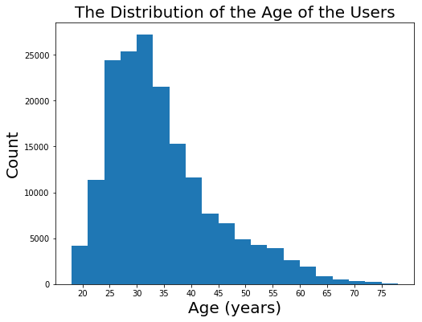

## (Age and Duration of Trip)

> **The scatter plot of the duration and age shows a weak negative relationship. The older the user, the shorter the duration of the trip as compared to the younger user. Younger people tend to spend more time riding.**

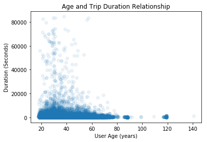

## (User types and Trip Duration)

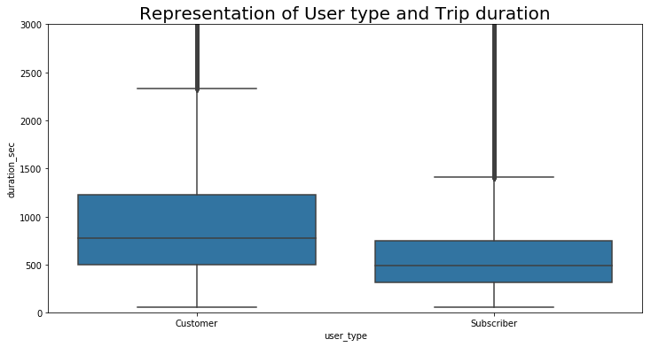

## (Duration of trips in relation to gender)

**Female had tend to take longer trips (duration) than male**

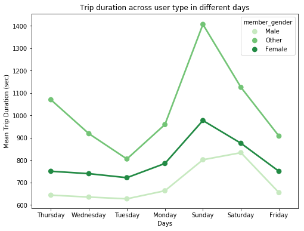

## (Day of the Week, Hour & User type Relationship)

> **The heatmap shows the distribution of rides during the weekdays, which depends on the hour of the day and day of the week. Week days are most active between the hours of (7-9 AM, 4-6 PM).**

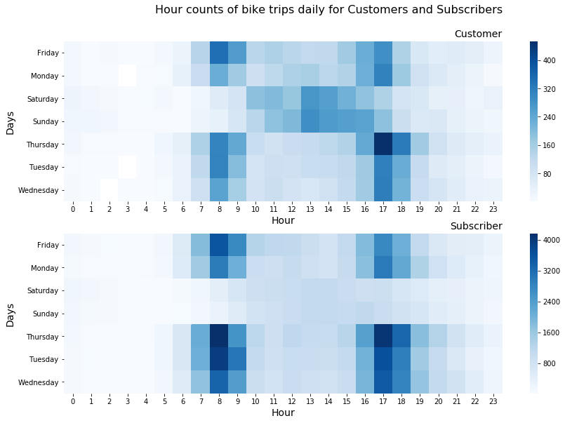